# Pacotes

```python
# Instalando o Tensor Flow

!pip install tensorflow -q
```

# 1 - Rede Neural Básica

## 1.1 Carregando os dados - Banco Imagens Projeto 2

```python
from google.colab import drive
drive.mount('/content/drive', force_remount= True)
```

# 1.2 Definição dos bancos de treino,teste, e validação.

```python
from tensorflow import keras
import pandas as pd
pd.set_option('display.max_columns', None)
import numpy as np


img_height = 200
img_width = 200

treino = keras.preprocessing.image_dataset_from_directory(
    '/content/drive/MyDrive/2022/FLS6497/FLS6497-ML/mapas/treino',
    labels='inferred',
    seed=44,
    image_size=(img_height, img_width),
    batch_size=32,
)

validacao = keras.preprocessing.image_dataset_from_directory(
    '/content/drive/MyDrive/2022/FLS6497/FLS6497-ML/mapas/validacao',
    labels='inferred',
    seed=44,
    image_size=(img_height, img_width),
    batch_size=32,
)

teste = keras.preprocessing.image_dataset_from_directory(
    '/content/drive/MyDrive/2022/FLS6497/FLS6497-ML/mapas/teste',
    labels='inferred',
    seed=44,
    image_size=(img_height, img_width),
    batch_size=32,
)


# Batch size alterado para 32 (anteriormente 64), por conta de melhora nos resultados do modelo.
```

```
Found 4000 files belonging to 2 classes.
Found 500 files belonging to 2 classes.
Found 500 files belonging to 2 classes.
```

Alteramos o batch size do preprocessamento das imagens pois isso fez o modelo apresentar uma melhora nas métricas de performance.

```python
# Checando o tipo resultante dos bancos

print(type(treino))
```

```
<class 'tensorflow.python.data.ops.dataset_ops.BatchDataset'>
```

```python
# Checando as categorias da classificação e se os formatos das imagens estão corretos

for data, labels in treino.take(1):
  print(data.shape)
  print(labels.shape)
```

```
(32, 200, 200, 3)
(32,)
```

```python
class_names = treino.class_names
print(class_names)
```

```
['rural', 'urbano']
```

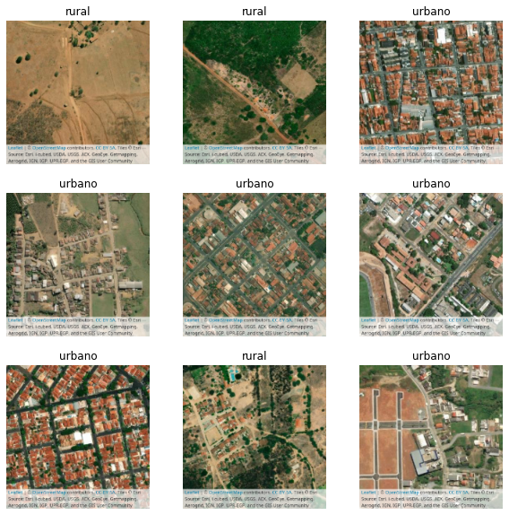

```python
import matplotlib.pyplot as plt


# Verificando se está tudo certo com o banco
plt.figure(figsize=(10, 10))
for images, labels in treino.take(1):
  for i in range(9):
    ax = plt.subplot(3, 3, i + 1)
    plt.imshow(images[i].numpy().astype("uint8"))
    plt.title(class_names[labels[i]])
    plt.axis("off")
```

# GPU do colab

```python
import tensorflow as tf

device_name = tf.test.gpu_device_name()
if device_name != '/device:GPU:0':
  print(
      '\n\nThis error most likely means that this notebook is not '
      'configured to use a GPU.  Change this in Notebook Settings via the '
      'command palette (cmd/ctrl-shift-P) or the Edit menu.\n\n')
  raise SystemError('GPU device not found')

elif device_name == '/device:GPU:0':
  print("GPU disponível")
```

```
GPU disponível
```

## Treinando o modelo baseline e avaliando seus resultados

```python
from tensorflow.keras import layers

# Garantindo que estamos usando a GPU
with tf.device('/device:GPU:0'):
  # Definindo a arquitetura do modelo
  model = keras.models.Sequential([
      layers.Rescaling(1./255, input_shape=(img_height, img_width, 3)),
      layers.Flatten(),
      layers.Dense(32,
                   activation="relu"),
      layers.Dense(1, activation="sigmoid")
  ])

  # Compila o Modelo
  model.compile(optimizer="adam",
                loss="binary_crossentropy",
                metrics=["accuracy","Precision", "Recall"])

  # Treina o modelo
  model.fit(treino,
            epochs=10,
            validation_data=validacao)
```

```python
# Salvando os resultados do modelo para verificação dos resultados por epoch.

epochs=10
history = model.fit(
  treino,
  validation_data=treino,
  epochs=epochs,
  verbose = 0
)
```

```python
# Output do modelo até o momento

model.summary()
```

```
Model: "sequential_2"
_________________________________________________________________
 Layer (type)                Output Shape              Param #
=================================================================
 rescaling_2 (Rescaling)     (None, 200, 200, 3)       0

 flatten_2 (Flatten)         (None, 120000)            0

 dense_4 (Dense)             (None, 32)                3840032

 dense_5 (Dense)             (None, 1)                 33

=================================================================
Total params: 3,840,065
Trainable params: 3,840,065
Non-trainable params: 0
_________________________________________________________________
```

## Visualizando os dados do treinamento

### Accuracy

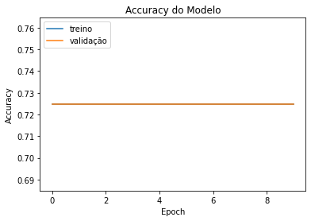

```python
from matplotlib import pyplot as plt

plt.plot(history.history['accuracy'])
plt.plot(history.history['val_accuracy'])
plt.title('Accuracy do Modelo')
plt.ylabel('Accuracy')
plt.xlabel('Epoch')
plt.legend(['treino', 'validação'], loc='upper left')
plt.show()
```

### Loss

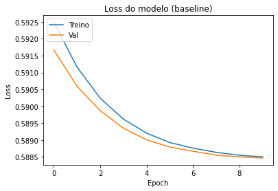

```python
# Loss

plt.plot(history.history['loss'])
plt.plot(history.history['val_loss'])
plt.title('Loss do modelo (baseline)')
plt.ylabel('Loss')
plt.xlabel('Epoch')
plt.legend(['Treino', 'Val'], loc='upper left')
plt.show()
```

### Validação no banco de Teste

```python
# Avaliando o modelo no dataset de teste

model.evaluate(teste)
```

```
[0.6344889998435974, 0.6759999990463257, 0.6759999990463257, 1.0]
```

## *Tuning* dos hiperparâmetros (Rede Neural Simples)

:Nessa parte, para facilitar a escolha dos hiperparâmetros, seguimos este [tutorial](https://www.analyticsvidhya.com/blog/2021/08/hyperparameter-tuning-of-neural-networks-using-keras-tuner/) e outro do [site](https://keras.io/guides/keras_tuner/custom_tuner/) oficial do Keras para automatizar esse processo.

Outros Links: [1](https://github.com/keras-team/keras-tuner/issues/122) [2](https://keras.io/guides/keras_tuner/getting_started/#tune-model-training)

```python
!pip install keras_tuner -q
```

```
     |████████████████████████████████| 135 kB 7.8 MB/s
     |████████████████████████████████| 1.6 MB 54.2 MB/s
```

Como a acurácia não mudou ao longo das epochs no último modelo, vamos alterar o otimizador para ver se há alguma mudança no resultado. Além disso, deixamos para o hyper_tuner decidir se algumas camadas devem ser adicionadas ou não (camada de *dropout*) e os valores das unidades e tipo de ativação para as camadas densas. O modo de escolha foi o *Random Search*.

```python
import keras_tuner
from tensorflow.keras import layers
from keras.optimizers import SGD


# Criando a classe do hypermodel
class MyHyperModel(keras_tuner.HyperModel):

    def build(self, hp):
      # Arquitetura do Modelo
        model = keras.Sequential()

        # Rescale

        model.add(layers.Rescaling(1./255, input_shape=(img_height, img_width, 3)))

        # Camada Flatten

        model.add(layers.Flatten())
        # 1° Camada Densa com tuning
        model.add(
            layers.Dense(
                units= hp.Int("units",
                              min_value=32,
                              max_value=512,
                              step=32), # Deixar o tuner decidir o número de unidades
                activation= hp.Choice("activation", ["relu", "tanh"]), # E o modo de ativação
            )
        )
        # Decidir se deve ou não usar dropout antes da camada de output
        if hp.Boolean("dropout"):
          model.add(layers.Dropout(rate=0.25))


        # Camada Densa final de output com 1 classes
        model.add(layers.Dense(1, # N° de Classes
                               activation="sigmoid") # Sigmoid é melhor para binário
                               )


        # Definindo os valores para a decisão do learning rate

        hp_learning_rate = hp.Choice('learning_rate', values=[1e-2, 1e-3, 1e-4])
        model.compile(
            optimizer=keras.optimizers.SGD(learning_rate=hp_learning_rate), # Alteramos o otimizador para ver se isso gera melhoras
            loss="binary_crossentropy",
            metrics=["accuracy", "Precision", "Recall"],
        )
        return model

    def fit(self, hp, model, *args, **kwargs):
        return model.fit(
            *args,
            # Tunando o batch size
            batch_size=hp.Int("batch_size", min_value = 16,
                              max_value = 128,
                              step = 16),
            **kwargs,
        )

tuner = keras_tuner.RandomSearch(
    MyHyperModel(),
    objective="val_accuracy",
    max_trials=5, # Aumentamos o número de trials para 5 por causa do space size
    overwrite=True,
    directory="my_dir",
    project_name="tune_hypermodel",
)
```

### Hypertuning de fato

```python
# hypertuning settings
tuner.search_space_summary()
```

```
Search space summary
Default search space size: 4
units (Int)
{'default': None, 'conditions': [], 'min_value': 32, 'max_value': 512, 'step': 32, 'sampling': None}
activation (Choice)
{'default': 'relu', 'conditions': [], 'values': ['relu', 'tanh'], 'ordered': False}
dropout (Boolean)
{'default': False, 'conditions': []}
learning_rate (Choice)
{'default': 0.01, 'conditions': [], 'values': [0.01, 0.001, 0.0001], 'ordered': True}
```

Rodando os trials

```python
# Parando os trials antes do tempo

stop_early = tf.keras.callbacks.EarlyStopping(monitor='val_loss', patience=3)

# Perform hypertuning
tuner.search(treino,
             epochs=5, # Menor número de epochs mas mais trials
             validation_data=validacao,
             callbacks=[stop_early])
```

```
Trial 5 Complete [00h 02m 42s]
val_accuracy: 0.7960000038146973

Best val_accuracy So Far: 0.7979999780654907
Total elapsed time: 00h 14m 16s
```

Resultados do Tuning

```python
# Melhores hiperparâmetros

best_hps = tuner.get_best_hyperparameters()[0]
print(best_hps.values)

# Melhor Modelo

best_model = tuner.get_best_models()[0]
best_model.summary()
```

```
{'units': 256, 'activation': 'tanh', 'dropout': False, 'learning_rate': 0.001, 'batch_size': 16}
Model: "sequential"
_________________________________________________________________
 Layer (type)                Output Shape              Param #
=================================================================
 rescaling (Rescaling)       (None, 200, 200, 3)       0

 flatten (Flatten)           (None, 120000)            0

 dense (Dense)               (None, 256)               30720256

 dense_1 (Dense)             (None, 1)                 257

=================================================================
Total params: 30,720,513
Trainable params: 30,720,513
Non-trainable params: 0
_________________________________________________________________
```

# Vendo os resultados no banco de validação

```python
best_model.fit(treino,
             epochs=1,
             validation_data=validacao)
```

```
<keras.callbacks.History at 0x7f5da7db6d90>
```

# Repetir os resultados em 10 epochs

Vamos rodar o modelo em 10 epochs e analisar os resultados.

```python
history = best_model.fit(treino,
             epochs=10,
             validation_data=validacao,
             verbose = 0)
```

### Accuracy

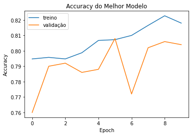

```python
plt.plot(history.history['accuracy'])
plt.plot(history.history['val_accuracy'])
plt.title('Accuracy do Melhor Modelo')
plt.ylabel('Accuracy')
plt.xlabel('Epoch')
plt.legend(['treino', 'validação'], loc='upper left')
plt.show()
```

### Loss

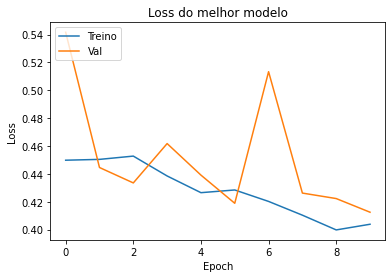

```python
plt.plot(history.history['loss'])
plt.plot(history.history['val_loss'])
plt.title('Loss do melhor modelo')
plt.ylabel('Loss')
plt.xlabel('Epoch')
plt.legend(['Treino', 'Val'], loc='upper left')
plt.show()
```

### Avaliando no banco de teste

```python
best_model.fit(treino,
             epochs=5,
             validation_data=validacao)



# Avaliando o modelo no dataset de teste

best_model.evaluate(teste)
```

```
[0.49392539262771606,
 0.7559999823570251,
 0.747706413269043,
 0.9644970297813416]
```

Com as mudanças do hypertuning, melhoramos a acurácia do modelo de rede neural simples de 67% para 75%.

# 2 - Rede neural convolucional

Iremos direto para o hypertuning do modelo convolucional e avaliação de seus resultados. Neste, adicionamos mais camadas do que o exemplo em aula e deixamos o hypertuner decidir principalmente se as camadas de dropout devem ou não existir.

```python
class ConvHyperModel(keras_tuner.HyperModel):
  # Criando a classe do hypermodel
    def build(self, hp):
      # Arquitetura do Modelo
        model = keras.Sequential()

        # Rescale

        model.add(layers.Rescaling(1./255, input_shape=(img_height, img_width, 3)))

        # 1° Camada Convolucional

        model.add(layers.Conv2D(32,
                                kernel_size=(3, 3),
                                activation='relu'))

        # 1° Pooling
        model.add(layers.MaxPooling2D((2, 2)))

        # 1° Dropout
        if hp.Boolean("dropout1"):
          model.add(layers.Dropout(rate=0.2))

        # 2° Camada Convolucional
        model.add(layers.Conv2D(64,
                                kernel_size=(3, 3),
                                activation='relu'))

        # 2° Pooling
        model.add(layers.MaxPooling2D((2, 2)))

        # 2° Dropout

        model.add(layers.Dropout(rate=0.3))


        # 3° Camada Convolucional
        model.add(layers.Conv2D(128,
                                kernel_size=(3, 3),
                                activation='relu'))


        # 3° Dropout
        if hp.Boolean("dropout2"):
          model.add(layers.Dropout(rate=0.4))

        # Flatten
        model.add(layers.Flatten())


        # Dense
        model.add(layers.Dense(128, activation = "relu"))


        # 4° Dropout
        if hp.Boolean("dropout3"):
          model.add(layers.Dropout(rate=0.3))


        # Camada densa final

        model.add(layers.Dense(1, activation='sigmoid'))


        # Definindo os valores para a decisão do learning rate
        hp_learning_rate = hp.Choice('learning_rate', values=[1e-2, 1e-3, 1e-4])
        model.compile(
            optimizer=keras.optimizers.Adam(learning_rate=hp_learning_rate),
            loss="binary_crossentropy",
            metrics=["accuracy", "Precision", "Recall"],
        )
        return model



    def fit(self, hp, model, *args, **kwargs):
        return model.fit(
            *args,
            # Tunando o batch size
            batch_size=hp.Int("batch_size", min_value = 16,
                              max_value = 128,
                              step = 16),
            **kwargs,
        )

tuner = keras_tuner.RandomSearch(
    ConvHyperModel(),
    objective="val_accuracy",
    max_trials=5,
    overwrite=True,
    directory="my_dir",
    project_name="tune_hypermodel",
)
```

```python
# hypertuning settings
tuner.search_space_summary()
```

[output not shown]

```python
# Parando os trials antes do tempo

stop_early = tf.keras.callbacks.EarlyStopping(monitor='val_loss', patience=3)

# Perform hypertuning
tuner.search(treino,
             epochs=5,
             validation_data=validacao,
             callbacks=[stop_early])
```

```
Trial 5 Complete [00h 01m 53s]
val_accuracy: 0.7739999890327454

Best val_accuracy So Far: 0.8880000114440918
Total elapsed time: 00h 13m 03s
```

```python
# Melhores hiperparâmetros

best_hps = tuner.get_best_hyperparameters()[0]
print(best_hps.values)

# Melhor Modelo

best_model = tuner.get_best_models()[0]
best_model.summary()
```

[output not shown]

```python
best_model.fit(treino,
             epochs=1,
             validation_data=validacao)
```

```
<keras.callbacks.History at 0x7f5d4224ad30>
```

## Repetindo os resultados em 10 epochs

```python
history = best_model.fit(treino,
             epochs=10,
             validation_data=validacao)
```

### Accuracy

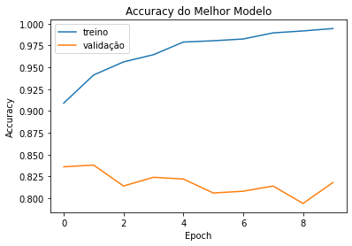

```python
plt.plot(history.history['accuracy'])
plt.plot(history.history['val_accuracy'])
plt.title('Accuracy do Melhor Modelo')
plt.ylabel('Accuracy')
plt.xlabel('Epoch')
plt.legend(['treino', 'validação'], loc='upper left')
plt.show()
```

### Precision

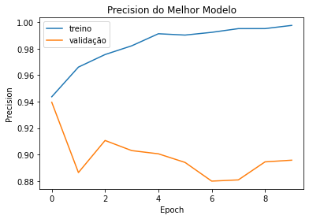

```python
plt.plot(history.history['precision'])
plt.plot(history.history['val_precision'])
plt.title('Precision do Melhor Modelo')
plt.ylabel('Precision')
plt.xlabel('Epoch')
plt.legend(['treino', 'validação'], loc='upper left')
plt.show()
```

### Recall

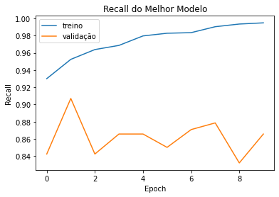

```python
plt.plot(history.history['recall'])
plt.plot(history.history['val_recall'])
plt.title('Recall do Melhor Modelo')
plt.ylabel('Recall')
plt.xlabel('Epoch')
plt.legend(['treino', 'validação'], loc='upper left')
plt.show()
```

### Loss

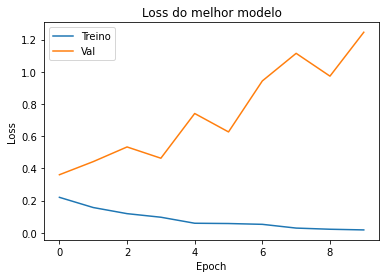

```python
plt.plot(history.history['loss'])
plt.plot(history.history['val_loss'])
plt.title('Loss do melhor modelo')
plt.ylabel('Loss')
plt.xlabel('Epoch')
plt.legend(['Treino', 'Val'], loc='upper left')
plt.show()
```

```python
# Avaliando o modelo no dataset de teste

best_model.evaluate(teste)
```

```
[1.461735725402832, 0.8259999752044678, 0.8702064752578735, 0.8727810382843018]
```

Conseguimos uma melhora de 75% para 82,6%. Iremos testar algumas configurações diferentes, como data augmentation e adicionar uma camada de dropout após a penúltima camada densa.

# Data augmentation (Rede Neural Convolucional).

Vamos aplicar a técnica de data augmentation e gerar novas observações por meio de rotações, zoom e giros horizontais das imagens originais, performados de forma aleatória.

```python
# Definição do método de data augmentation.

data_augmentation = keras.Sequential(
  [
    layers.RandomFlip("horizontal",
                      input_shape=(img_height,
                                  img_width,
                                  3)),
    layers.RandomRotation(0.1),
    layers.RandomZoom(0.1),
  ]
)
```

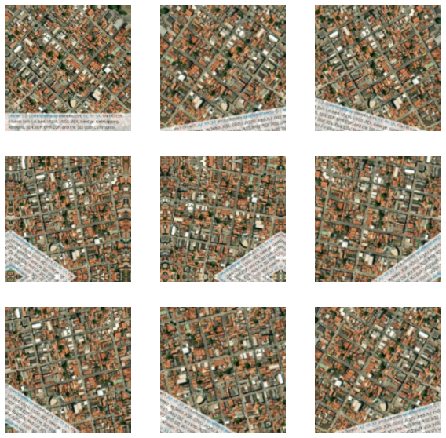

```python
# Plotando exemplos de possíveis gerações de imagens

plt.figure(figsize=(10, 10))

for images, labels in treino.take(1):
  for i in range(9):
    augmented_images = data_augmentation(images,
                                         training = True) # Necessário pois sem isso não funcionava
    ax = plt.subplot(3, 3, i + 1)
    plt.imshow(augmented_images[0].numpy().astype("uint8"))
    plt.axis("off")
```

```python
# Definindo a classe do modelo convolucional com data augmentation

class ConvHyperModel2(keras_tuner.HyperModel):
  # Criando a classe do hypermodel
    def build(self, hp):
      # Arquitetura do Modelo
        model = keras.Sequential()

        # Data Augmentation

        model.add(data_augmentation)

        # Rescale

        model.add(layers.Rescaling(1./255, input_shape=(img_height, img_width, 3)))

        # 1° Camada Convolucional

        model.add(layers.Conv2D(32,
                                kernel_size=(3, 3),
                                activation='relu'))

        # 1° Pooling
        model.add(layers.MaxPooling2D((2, 2)))

        # 1° Dropout
        if hp.Boolean("dropout1",
                      default = True):
          model.add(layers.Dropout(rate=0.2))

        # 2° Camada Convolucional
        model.add(layers.Conv2D(64,
                                kernel_size=(3, 3),
                                activation='relu'))

        # 2° Pooling
        model.add(layers.MaxPooling2D((2, 2)))

        # 2° Dropout

        model.add(layers.Dropout(rate=0.3))


        # 3° Camada Convolucional
        model.add(layers.Conv2D(128,
                                kernel_size=(3, 3),
                                activation='relu'))


        # 3° Dropout
        if hp.Boolean("dropout3",
                      default = True):
          model.add(layers.Dropout(rate=0.4))

        # Flatten
        model.add(layers.Flatten())


        # Dense
        model.add(layers.Dense(128, activation = "relu"))


        # 4° Dropout
        model.add(layers.Dropout(rate=0.3))


        # Camada densa final

        model.add(layers.Dense(1, activation='sigmoid'))


        # Definindo os valores para a decisão do learning rate
        hp_learning_rate = hp.Choice('learning_rate', values=[1e-2, 1e-3, 1e-4])
        model.compile(
            optimizer=keras.optimizers.Adam(learning_rate=hp_learning_rate),
            loss="binary_crossentropy",
            metrics=["accuracy", "Precision", "Recall"],
        )
        return model



    def fit(self, hp, model, *args, **kwargs):
        return model.fit(
            *args,
            # Tunando o batch size
            batch_size=hp.Int("batch_size", min_value = 16,
                              max_value = 128,
                              step = 16),
            **kwargs,
        )

tuner = keras_tuner.RandomSearch(
    ConvHyperModel2(),
    objective="val_accuracy",
    max_trials=5,
    overwrite=True,
    directory="my_dir",
    project_name="tune_hypermodel",
)
```

```python
# hypertuning settings
tuner.search_space_summary()
```

```
Search space summary
Default search space size: 3
dropout1 (Boolean)
{'default': True, 'conditions': []}
dropout3 (Boolean)
{'default': True, 'conditions': []}
learning_rate (Choice)
{'default': 0.01, 'conditions': [], 'values': [0.01, 0.001, 0.0001], 'ordered': True}
```

```python
# Parando os trials antes do tempo

stop_early = tf.keras.callbacks.EarlyStopping(monitor='val_loss', patience=3)

# Perform hypertuning
tuner.search(treino,
             epochs=10,
             validation_data=validacao,
             callbacks=[stop_early])
```

```
Trial 5 Complete [00h 02m 11s]
val_accuracy: 0.7739999890327454

Best val_accuracy So Far: 0.8939999938011169
Total elapsed time: 00h 25m 51s
```

```python
# Melhores hiperparâmetros

best_hps = tuner.get_best_hyperparameters()[0]
print(best_hps.values)

# Melhor Modelo

best_model = tuner.get_best_models()[0]
best_model.summary()
```

```
{'dropout1': False, 'dropout3': False, 'learning_rate': 0.0001, 'batch_size': 16}
Model: "sequential"
_________________________________________________________________
 Layer (type)                Output Shape              Param #
=================================================================
 sequential_1 (Sequential)   (None, 200, 200, 3)       0

 rescaling (Rescaling)       (None, 200, 200, 3)       0

 conv2d (Conv2D)             (None, 198, 198, 32)      896

 max_pooling2d (MaxPooling2D  (None, 99, 99, 32)       0
 )

 conv2d_1 (Conv2D)           (None, 97, 97, 64)        18496

 max_pooling2d_1 (MaxPooling  (None, 48, 48, 64)       0
 2D)

 dropout (Dropout)           (None, 48, 48, 64)        0

 conv2d_2 (Conv2D)           (None, 46, 46, 128)       73856

 flatten (Flatten)           (None, 270848)            0

 dense (Dense)               (None, 128)               34668672

 dropout_1 (Dropout)         (None, 128)               0

 dense_1 (Dense)             (None, 1)                 129

=================================================================
Total params: 34,762,049
Trainable params: 34,762,049
Non-trainable params: 0
_________________________________________________________________
```

```python
best_model.fit(treino,
             epochs=1,
             validation_data=validacao)
```

```
<keras.callbacks.History at 0x7f5d224c7d90>
```

## Repetindo os resultados em 10 epochs

```python
history = best_model.fit(treino,
             epochs=10,
             validation_data=validacao)
```

### Accuracy

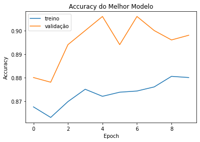

```python
plt.plot(history.history['accuracy'])
plt.plot(history.history['val_accuracy'])
plt.title('Accuracy do Melhor Modelo')
plt.ylabel('Accuracy')
plt.xlabel('Epoch')
plt.legend(['treino', 'validação'], loc='upper left')
plt.show()
```

### Loss

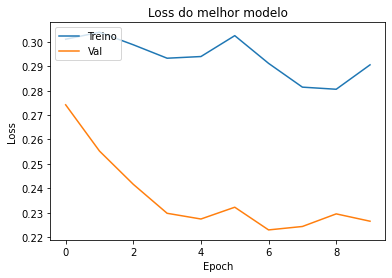

```python
plt.plot(history.history['loss'])
plt.plot(history.history['val_loss'])
plt.title('Loss do melhor modelo')
plt.ylabel('Loss')
plt.xlabel('Epoch')
plt.legend(['Treino', 'Val'], loc='upper left')
plt.show()
```

### Precision

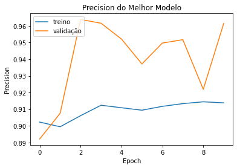

```python
plt.plot(history.history['precision'])
plt.plot(history.history['val_precision'])
plt.title('Precision do Melhor Modelo')
plt.ylabel('Precision')
plt.xlabel('Epoch')
plt.legend(['treino', 'validação'], loc='upper left')
plt.show()
```

### Recall

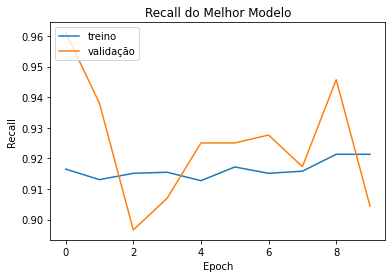

```python
plt.plot(history.history['recall'])
plt.plot(history.history['val_recall'])
plt.title('Recall do Melhor Modelo')
plt.ylabel('Recall')
plt.xlabel('Epoch')
plt.legend(['treino', 'validação'], loc='upper left')
plt.show()
```

### Avaliando no banco de Teste

O modelo tem o melhor resultado em 5 épocas, ele será retreinado e testado no banco de teste

```python
best_model.fit(treino,
             epochs=5,
             validation_data=validacao)


print(" ")
print("Avaliando no banco de Teste")
best_model.evaluate(teste)
```

```
Avaliando no banco de Teste
```

```
[0.26496103405952454,
 0.8980000019073486,
 0.925815999507904,
 0.9230769276618958]
```